# Chatlize generated report

https://Chatlize.ai

2023-07-18

### System

**Act as an experienced data scientist and statistician. Write R code to analyze data following instructions.**

### Step 1

Prompt: Write R code. Do not include explanation. Read the file ‘RNAseq.csv’ in the current folder and print a small part of it. Treat the first column is row names. These rest of columns are read counts data from RNA-Seq, each representing a sample. The first three columns are control samples. The last three are treated with radiation.

```r
data <- read.csv('RNAseq.csv', row.names = 1)
head(data)
```

```
##                    mock_1 mock_2 mock_3 IR_1 IR_2 IR_3
## ENSMUSG00000028995   3210   2553   2096 1054  663 1012
## ENSMUSG00000045007    122     97     53   22   10   15
## ENSMUSG00000062785    183    182    143  530  384  590
## ENSMUSG00000038268   1117    843    669  526  369  654
## ENSMUSG00000054589     85     46     36  693  394  865
## ENSMUSG00000102752     52     59     45   21   16   20
```

### Step 2

Prompt: Write R code. Do not include explanation. Caculate total reads for all samples. Create a barplot.

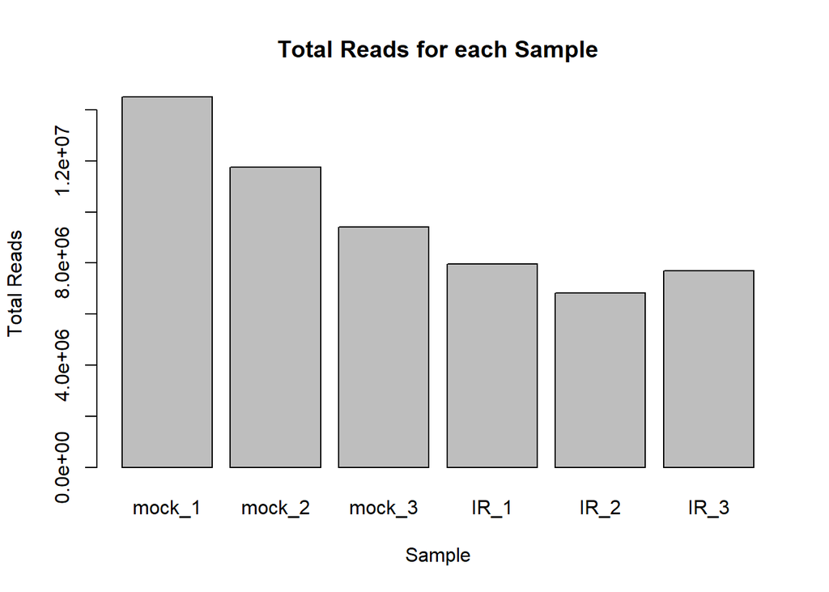

```r
total_reads <- colSums(data)
barplot(total_reads, main = "Total Reads for each Sample", xlab = "Sample", ylab = "Total Reads")
```

### Step 3

Prompt: Write R code. Do not include explanation. Calculate counts per million (CPM) from raw counts. Filter the data by removing genes with CPM less than 10 in all samples. Print the number of genes removed.

```r
cpm <- 1000000 * data / colSums(data)
filtered_data <- cpm[rowSums(cpm >= 10) > 0, ]
genes_removed <- nrow(data) - nrow(filtered_data)
print(genes_removed)
```

```
## [1] 2095
```

### Step 4

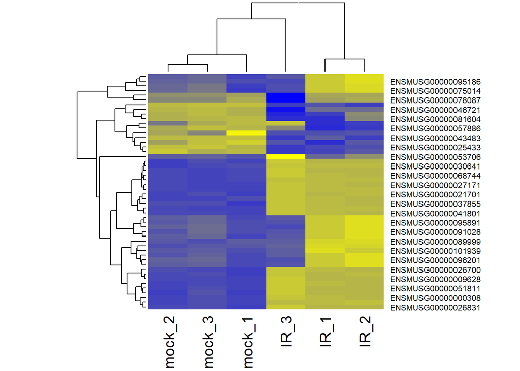

```r
filtered_data <- filtered_data + 1
log_data <- log2(filtered_data)
sorted_data <- log_data[order(apply(log_data, 1, sd), decreasing = TRUE), ]
data_matrix <- as.matrix(sorted_data)
centered_data <- t(t(data_matrix) - colMeans(data_matrix))
top_50_genes <- centered_data[1:50, ]
heatmap(top_50_genes, col = colorRampPalette(c("blue", "yellow"))(50))
```

### Step 5

Prompt: Write R code. Do not include explanation. From the raw count data, remove genes not included in the filtered CPM data. Use the resultant data to identify differentially expressed genes with the DESeq2 package. The first three columns are control samples. The last three are treated with radiation. Remove genes with any missing values in the DESeq2 results. Identify the significant genes with FDR < 0.05 and log fold change > 1. Show the number of significantly up or downregulated genes.

```r
pacman::p_load(DESeq2)
raw_count_filtered <- data[row.names(filtered_data), ]
dds <- DESeqDataSetFromMatrix(countData = raw_count_filtered,
                              colData = data.frame(condition = factor(c(rep("Control", 3), rep("Radiation", 3)))),
                              design = ~ condition)
dds <- DESeq(dds)
deseq_results <- results(dds)
deseq_results <- deseq_results[!is.na(deseq_results$padj), ]
significant_genes <- subset(deseq_results, padj < 0.05 & abs(log2FoldChange) > 1)
num_upregulated <- sum(significant_genes$log2FoldChange > 0)
num_downregulated <- sum(significant_genes$log2FoldChange < 0)
print(paste("Number of significantly upregulated genes:", num_upregulated))
```

```
## [1] "Number of significantly upregulated genes: 1092"
```

```r
print(paste("Number of significantly downregulated genes:", num_downregulated))
```

```
## [1] "Number of significantly downregulated genes: 312"
```

### Step 6

Prompt: Write R code. Do not include explanation. Sort the significant genes by the log fold change in descending order. Print the top 5 up and down regulated genes, their fold-change, and original read counts in all samples.

```r
sorted_genes <- significant_genes[order(-abs(significant_genes$log2FoldChange)), ]
top_5_upregulated <- head(sorted_genes[sorted_genes$log2FoldChange > 0, ], 5)
top_5_downregulated <- head(sorted_genes[sorted_genes$log2FoldChange < 0, ], 5)

print("Top 5 upregulated genes:")
```

```
## [1] "Top 5 upregulated genes:"
```

```r
print(top_5_upregulated[, c("baseMean", "log2FoldChange", "lfcSE", "pvalue", "padj")])
```

```
## log2 fold change (MLE): condition Radiation vs Control
## Wald test p-value: condition Radiation vs Control
## DataFrame with 5 rows and 5 columns
##                       baseMean log2FoldChange     lfcSE      pvalue        padj
##                      <numeric>      <numeric> <numeric>   <numeric>   <numeric>
## ENSMUSG00000101939   1153.2075       11.14635   2.80106 6.91069e-05 1.88800e-04
## ENSMUSG00000026831    221.1361       10.80187   1.23539 2.25667e-18 1.70445e-17
## ENSMUSG00000075014 488893.4931        9.56288   2.13388 7.41365e-06 2.28381e-05
## ENSMUSG00000000308     88.8865        9.48751   1.23499 1.56282e-14 9.12315e-14
## ENSMUSG00000075015  80405.3668        9.42645   2.12448 9.11977e-06 2.78072e-05
```

```r
print("Top 5 downregulated genes:")
```

```
## [1] "Top 5 downregulated genes:"
```

```r
print(top_5_downregulated[, c("baseMean", "log2FoldChange", "lfcSE", "pvalue", "padj")])
```

```
## log2 fold change (MLE): condition Radiation vs Control
## Wald test p-value: condition Radiation vs Control
## DataFrame with 5 rows and 5 columns
##                     baseMean log2FoldChange     lfcSE      pvalue        padj
##                    <numeric>      <numeric> <numeric>   <numeric>   <numeric>
## ENSMUSG00000066315  453.1454      -11.74551  2.536920 3.65962e-06 1.16489e-05
## ENSMUSG00000043483  454.1425       -6.11187  2.129527 4.10392e-03 8.75540e-03
## ENSMUSG00000061311   70.9049       -4.42213  0.583707 3.56534e-14 2.02928e-13
## ENSMUSG00000046721 1239.0090       -3.93275  1.743743 2.41112e-02 4.34183e-02
## ENSMUSG00000025433   91.8584       -3.79190  0.413001 4.25776e-20 3.55880e-19
```

```r
print("Original read counts for all samples:")
```

```
## [1] "Original read counts for all samples:"
```

```r
print(raw_count_filtered[c(row.names(top_5_upregulated), row.names(top_5_downregulated)), ])
```

```
##                    mock_1 mock_2 mock_3   IR_1    IR_2 IR_3
## ENSMUSG00000101939      0      2      2   3960     977    0
## ENSMUSG00000026831      0      1      0    271     172  532
## ENSMUSG00000075014     92   1562   3222 588450 1171830  225
## ENSMUSG00000000308      1      0      0    127      77  183
## ENSMUSG00000075015     19    281    582  96833  192652   37
## ENSMUSG00000066315   4435    260     61      0       0    0
## ENSMUSG00000043483   1694   1177   1080     30       0    0
## ENSMUSG00000061311    241    249    114      5       6    2
## ENSMUSG00000046721   3214   3197   3474    172     127    0
## ENSMUSG00000025433    262    257    221     11       8    7
```

### Step 7

Prompt: Write R code. Do not include explanation. Create a volcano plot.

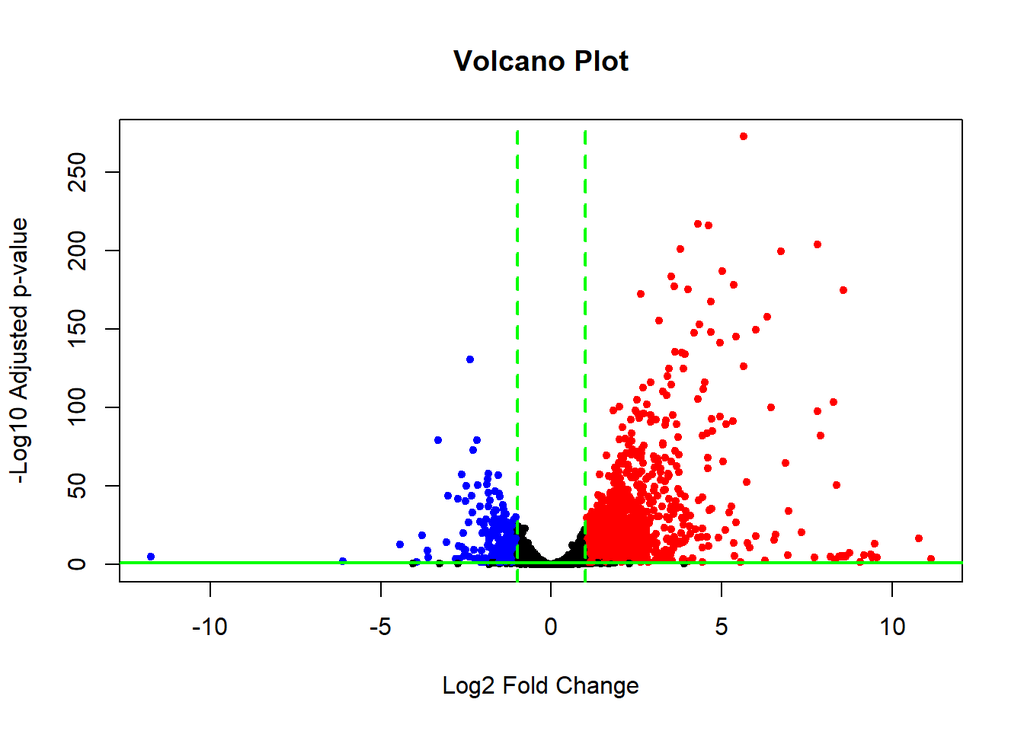

```r
volcano_plot <- function(results, fc_threshold, pval_threshold) {
  upregulated <- results$log2FoldChange > fc_threshold & results$padj < pval_threshold
  downregulated <- results$log2FoldChange < -fc_threshold & results$padj < pval_threshold

  plot(results$log2FoldChange, -log10(results$padj), pch = 20,
       col = ifelse(upregulated, "red", ifelse(downregulated, "blue", "black")),
       main = "Volcano Plot",
       xlab = "Log2 Fold Change",
       ylab = "-Log10 Adjusted p-value")

  abline(h = -log10(pval_threshold), col = "green", lwd = 2)
  abline(v = c(-fc_threshold, fc_threshold), col = "green", lwd = 2, lty = 2)
}

volcano_plot(deseq_results, 1, 0.05)
```

Generated with https://Chatlize.ai. No guarantees! Still a work in progress. Contact Steven Ge (gexijin@gmail.com).